# Kursusintroduktion

Finansiering 2026 · HA.jur.

Niklas Lehmann Jensen

## Hvem betaler, når historien tager en drejning?

Et obligationslån skaffer penge nu mod et løfte om betaling senere.

[figure not shown]

Inspireret af Robin Wigglesworths *A Fabulous Debt*. Kilder følger på de enkelte slides.

## Venedig låner til en krigsflåde

1171–72 → 1262 · Venedig

- Kejseren i Det Byzantinske Rige fængsler venetianske købmænd og beslaglægger deres ejendom. Venedig sender en flåde for at få dem frigivet.
- Staten tvinger velhavende borgere til at låne den penge.
- Borgerne får et tilgodehavende hos staten.
- Fra 1262 findes et organiseret marked for gælden.
- Borgerne kan sælge deres tilgodehavender og få pengene før statens tilbagebetaling.

[figure not shown]

Venedigs havn, malet af Canaletto i 1742–44. National Gallery of Art, public domain.

Kilder: [Schmelzing (2020), s. 18–19](https://www.bankofengland.co.uk/-/media/boe/files/working-paper/2020/eight-centuries-of-global-real-interest-rates-r-g-and-the-suprasecular-decline-1311-2018) · [Pezzolo (2005)](https://iris.unive.it/handle/10278/4445)

## Et hollandsk digelån betaler stadig renter

1600-tallet · Nederlandene

- Hollænderne gør offentlige lån til en bredere opsparingsform med skatter og afgifter til at betale renterne.
- Långivere kan overdrage gælden eller bruge den som sikkerhed for egne lån. Pengene er dermed lettere at få adgang til igen.
- Et lån fra 1648 finansierer arbejde på diger og flodbredder.
- Lånet har ingen fast udløbsdato: renterne kan fortsætte i generationer.
- Yale ejer obligationen i dag og kan stadig opkræve renter.

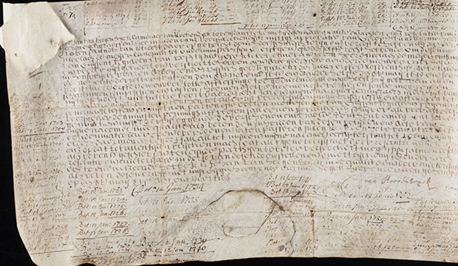

Obligationen fra 1648. Beinecke Library, Yale University. Digital gengivelse af et historisk dokument.

Kilder: [Gelderblom & Jonker (2011)](https://people.bu.edu/chamley/HSFref/GelderblomJonkerJEH11.pdf) · [Yale (2015)](https://news.yale.edu/2015/09/22/living-artifact-dutch-golden-age-yale-s-367-year-old-water-bond-still-pays-interest) · [Yale (2026)](https://som.yale.edu/story/2026/prof-rouwenhorst-discusses-yales-378-year-old-perpetual-bond-bbc)

## Storbritannien kan låne sig til at holde ud

1694 → 1815 · England og senere Storbritannien

- England henter inspiration i hollandske lån med skatteindtægter til renterne og værdipapirer, som investorer kan sælge videre.
- Bank of England oprettes i 1694 og låner staten £1,2 mio. til krig.
- Skatter og en troværdig betalingshistorik gør store lån mulige.
- Under Napoleonskrigene har briterne lettere adgang til lån end Frankrig.
- Lån finansierer flåde, hær og allierede gennem en lang krig.

[figure not shown]

Napoleon i 1812, malet af Jacques-Louis David. National Gallery of Art, public domain.

Kilder: [Newton Project, Oxford](https://dev.newtonproject.ox.ac.uk/introduction/the-financial-revolution) · [Bank of England](https://www.bankofengland.co.uk/freedom-of-information/2020/details-of-the-bank-of-england-loan-to-the-government-in-1694) · [Bordo & White (1991)](https://www.researchwithrutgers.org/en/publications/a-tale-of-two-currencies-british-and-french-finance-during-the-na/)

## København skal genopbygges efter branden

1795–97 · Danmark

- Branden i 1795 ødelægger over 900 ejendomme i København.
- Genopbygningen kræver mere kapital, end husejerne selv har.
- I 1797 oprettes Husejernes Kreditkasse på långivernes initiativ.
- Obligationer skaffer penge til lån med sikkerhed i ejendommene.
- Det bliver begyndelsen på dansk realkredit, som vi møder i kapitel 5.

[figure not shown]

Gammeltorv og rådhuset under branden i 1795. Gengivet i *En kjøbenhavnsk Embedsmand* (1918), public domain.

Kilder: [Finans Danmark](https://finansdanmark.dk/realkredit/dansk-realkredit/realkredittens-historie/) · [Andersen (1947), Kreditkassen for Husejerne i Kjøbenhavn](https://jura.ku.dk/jurabog/pdf/juridiske-monografier/andersen_kreditkassen_for_husejerne_i_kjoebenhavn_1947.pdf)

## USA køber Louisiana med lånte penge

1803 · USA, efter Hamiltons gældsreform

- Hamiltons reform fra 1790 har samlet krigsgæld hos forbundsstaten.
- Told og afgifter skal sikre, at staten betaler sine kreditorer.
- I 1803 køber USA Louisiana af Frankrig for 15 mio. dollar.
- Frankrig får 11,25 mio. dollar i obligationer med 6 % rente.
- USA bliver omtrent dobbelt så stort; Napoleon får midler til sine europæiske planer.

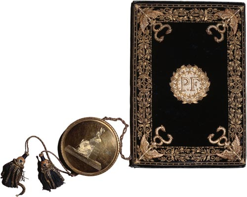

Louisiana-traktatens omslag og seglkapsel, 1803. National Archives, USA. Territoriet rækker langt ud over nutidens Louisiana.

Kilder: [U.S. Treasury](https://home.treasury.gov/about/history/prior-secretaries/alexander-hamilton-1789-1795) · [Traktaten, 1803](https://www.archives.gov/milestone-documents/louisiana-purchase-treaty) · [Office of the Historian](https://history.state.gov/milestones/1801-1829/louisiana-purchase)

## Chaplin sælger obligationer til amerikanerne

1917–18 · USA går ind i Første Verdenskrig

- USA skal hurtigt skaffe penge til krigen mod Tyskland.
- Fire Liberty Loan-kampagner sælger krigsobligationer til befolkningen.
- En obligation kan købes for 50 dollar og giver renter til køberen.
- Charlie Chaplin og andre filmstjerner trækker folk til salgsmøderne.
- Propagandaen gør obligationskøb til en patriotisk handling og udmaler fjenden som brutal.

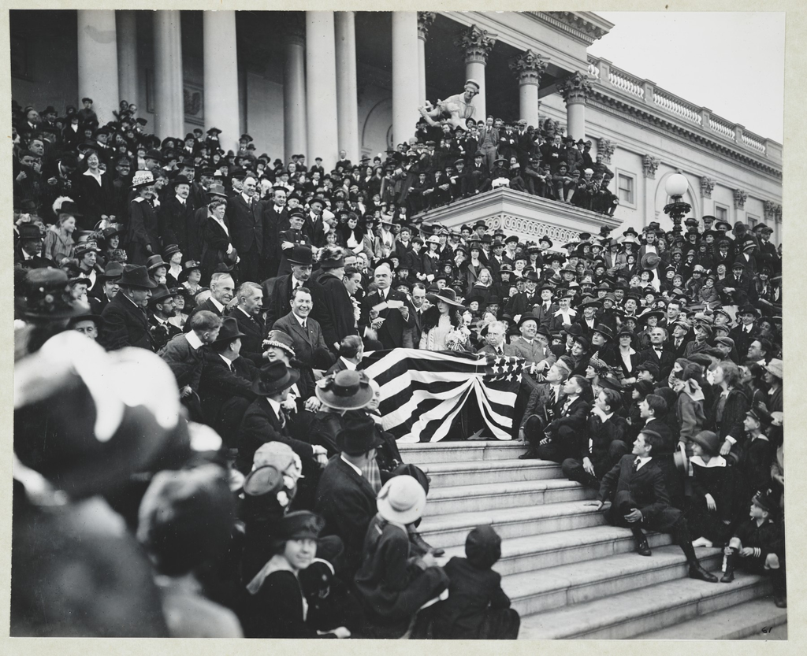

Chaplin og Repræsentanternes Hus’ formand, Champ Clark, 1918. Library of Congress / U.S. Capitol Visitor Center.

Kilder: [Federal Reserve History](https://www.federalreservehistory.org/essays/liberty-bonds) · [U.S. Capitol Visitor Center](https://www.visitthecapitol.gov/artifact/liberty-bond-rally-us-capitol-photograph-1918) · [National Park Service](https://www.nps.gov/articles/000/over-here-over-there-america-and-world-war-i.htm)

## Krigsindsatsen bliver et argument for rettigheder

1917–20 · Hvem får fuldt medborgerskab?

- Kvinder både køber obligationer og organiserer salget.
- Efter en samtidig opgørelse var knap hver tredje køber i første kampagne en kvinde.
- Wilson bruger kvinders krigsindsats som argument for stemmeret i 1918.
- Afroamerikanere støtter også krigslånene og håber på større lighed.
- I 1920 sikres kvinders stemmeret i forfatningen. Racistiske valgregler holder stadig mange afroamerikanere ude.

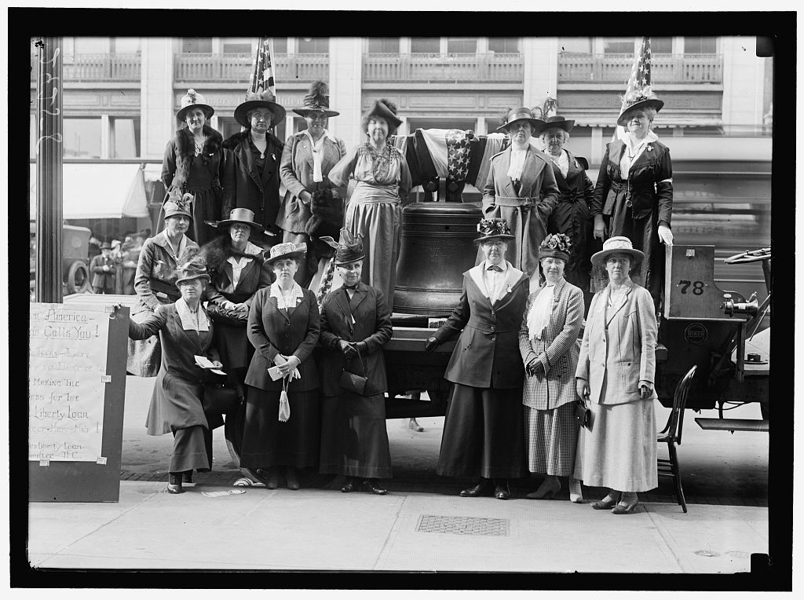

Kvindekomité ved den tredje Liberty Loan, 1918. Harris & Ewing / Library of Congress.

Kilder: [Clarke (1918), kap. IX](https://www.gwpda.org/wwi-www/Clarke/Clarke09.htm) · [Wilson, 30/9 1918](https://www.presidency.ucsb.edu/documents/address-the-senate-the-nineteenth-amendment) · [National Park Service](https://www.nps.gov/articles/000/over-here-over-there-america-and-world-war-i.htm)

## Milken åbner obligationsmarkedet for flere virksomheder

1970–80’erne · Michael Milken, Drexel Burnham Lambert

- Virksomheder under *investment grade* har en lavere kreditvurdering og større risiko for ikke at betale.
- Deres obligationer kaldes *high yield* eller *junk bonds*. Investorerne kræver derfor højere renter.
- Milken samler investorer og skaber et stort marked for nye udstedelser fra disse virksomheder.
- Flere virksomheder kan låne til investeringer og opkøb. High yield bliver en varig finansieringskilde.
- Gælden kan også blive for tung. Milken erkender i 1990 seks lovbrud, bl.a. værdipapirsvindel.

[figure not shown]

Michael Milken, 2006. U.S. Congress / [Wikimedia Commons](https://commons.wikimedia.org/wiki/File:Michael_Milken_1.jpg), public domain.

Kilder: [Titman (2001), s. 10–11](https://www.nber.org/papers/w8641) · [SEC (1990), s. 8](https://www.sec.gov/about/annual_report/1990.pdf)

## Ranieri forbinder boliglån med Wall Street

1970–80’erne → 2007–09 · Lewis Ranieri, Salomon Brothers

- Babyboom-generationen søger bolig, mens Volcker bekæmper inflationen med høje renter fra 1979.
- Boliglångivere presses mellem gamle lån med lav, fast rente og dyrere finansiering.
- Ranieri udbygger markedet for MBS: værdipapirer betalt af renter og afdrag fra puljer af boliglån.
- Investorer kan få renteindtægter fra mange boliglån i én investering. Deres penge giver flere familier mulighed for at finansiere en bolig.
- Risikable lån pakkes senere i lag med forskellig tabsrisiko. Risikoen undervurderes, og tabene bidrager til finanskrisen.

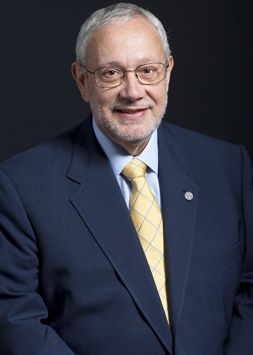

Lewis Ranieri. Portræt fra [Ranieri Solutions](https://www.ranierisolutions.com/).

Dansk realkredit har et balanceprincip, der knytter lån og obligationer tæt sammen. Amerikanske værdipapirer med lag af tabsrisiko er opbygget anderledes. Se kapitel 5 og 9.

Kilder: [Sparekassekrisen, Federal Reserve](https://www.federalreservehistory.org/essays/savings-and-loan-crisis) · [Federal Reserve (2007)](https://www.federalreserve.gov/newsevents/speech/bernanke20070831a.htm) · [FCIC (2011), s. 67–70 og 88–89](https://www.govinfo.gov/content/pkg/GPO-FCIC/pdf/GPO-FCIC.pdf)

## Fra boliglån til finanskriser

- Hvad bestemmer renten på et lån?
- Hvorfor falder en obligations pris, når renten stiger?
- Hvem bærer risikoen i dansk realkredit?
- Hvordan kan finansielle tab brede sig til resten af økonomien?

## Niklas Lehmann Jensen

Jeres underviser

- **2021:** Cand.oecon. fra Aarhus Universitet.
- **2021–2023 · Sydbank:** Analytiker inden for porteføljemanagement og risikomodeller.
- **Siden 2023 · Scanrate:** Senioranalytiker.
- **Fra 2022 · SDU:** Undervisning i matematik og makroøkonomi på HA Almen.
- **Siden 2024 · AU:** Undervisning i finansiering.

## Seks uger, to møder om ugen

**19. oktober – 26. november 2026**

| Dag | Tid | Lokale |
| --- | --- | --- |
| Mandag 19/10 | 16.00–18.00 | 1830-211 |
| Tirsdage fra 20/10 | 08.00–10.00 | 1810-211 |
| Torsdage fra 29/10 | 14.00–16.00 | 1830-211 |

12 undervisningsmoduler. Første uge: mandag og tirsdag. Derefter: tirsdag og torsdag. Ændringer findes på Brightspace.

## Renter, obligationer og realkredit

| Modul | Dato | Indhold |
| --- | --- | --- |
| 1 | 19/10 | Intro + kapitel 1: Rentedannelsen |
| 2 | 20/10 | Kapitel 2: Obligationsmarkedet |
| 3 | 27/10 | Kapitel 3: Rentestrukturen |
| 4 | 29/10 | Kapitel 4: Risikomål |
| 5 | 03/11 | Kapitel 5: Dansk realkredit |
| 6 | 05/11 | Kapitel 6: Konverteringsadfærd |

## Pris, afkast, risiko og eksamensarbejde

| Modul | Dato | Indhold |
| --- | --- | --- |
| 7 | 10/11 | Kapitel 7: Prisfastsættelse og nøgletal |
| 8 | 12/11 | Kapitel 8: Obligationsafkast |
| 9 | 17/11 | Kapitel 9: Finanskrisen |
| 10 | 19/11 | Kapitel 10: Pengeinstitutternes risiko |
| 11 | 24/11 | Buffer og opsamling |
| 12 | 26/11 | Tidligere eksamen som eksempel |

## Materialet er samlet på forsiden

- **Lektionsnoter i finansiering 2026:** ti kapitler.
- **Slides:** browserudgave og PDF til hvert kapitel.
- **OS1–OS5:** øvelsessæt til selvstændigt arbejde.
- **Brightspace:** beskeder, lokale og eksamensoplysninger.

## Smagsprøve på centrale formler

**Pris på en kuponobligation · kapitel 2**

$$P=\sum_{t=1}^{N}\frac{C}{(1+y)^t}+\frac{H}{(1+y)^N}$$

Kuponer og hovedstol diskonteres til i dag.

**Kronevarighed · kapitel 4**

$$d=\frac{D}{1+y}\frac{K}{100}=MD\frac{K}{100}$$

Omtrentligt kursfald ved +1 procentpoint rente.

**Kronekonveksitet · kapitel 4**

$$\mathrm{Cvx}_{\mathrm{KR}}=\frac{0{,}01^2}{(1+y)^2}\sum_t t(t+1)PV(CF_t)$$

Tager højde for krumningen i kursens reaktion.

**Konverteringsgevinst · kapitel 6**

$$Gain_t=\frac{PV_{\mathrm{continue},t}-100(1+cost_t)}{PV_{\mathrm{continue},t}}$$

Besparelsen ved pariindfrielse, efter omkostninger.

## Vi skal kunne forklare det, vi regner

1. Læs kapitlet før undervisningen.
2. Følg betalinger, enheder og forudsætninger i eksemplerne.
3. Spørg, hvad der ændrer sig, når vi ændrer en rente eller antagelse.
4. Regn selv videre med øvelsessættene.

## Spørg i timen eller skriv en mail

**Niklas Lehmann Jensen**

nlj@econ.au.dk  
niklas@scanrate.dk

Vi gennemgår en tidligere eksamen den **26. november**. Aktuel eksamensdato, prøveform og hjælpemidler fremgår af universitetets eksamensinformation.